# TP3

Guillaume, Julio, Pierre-Yves

24 avril 2019

TP3

#Exercice 1

##1/1ecture du fichier

```r
tab=read.csv("Advertising.csv",header=T,row.names=1)
attach(tab)
summary(tab)
```

```
##        TV             Radio          Newspaper          Sales
##  Min.   :  0.70   Min.   : 0.000   Min.   :  0.30   Min.   : 1.60
##  1st Qu.: 74.38   1st Qu.: 9.975   1st Qu.: 12.75   1st Qu.:10.38
##  Median :149.75   Median :22.900   Median : 25.75   Median :12.90
##  Mean   :147.04   Mean   :23.264   Mean   : 30.55   Mean   :14.02
##  3rd Qu.:218.82   3rd Qu.:36.525   3rd Qu.: 45.10   3rd Qu.:17.40
##  Max.   :296.40   Max.   :49.600   Max.   :114.00   Max.   :27.00
```

```r
pub=data.frame(data=tab)
summary(pub)
```

```
##     data.TV         data.Radio     data.Newspaper     data.Sales
##  Min.   :  0.70   Min.   : 0.000   Min.   :  0.30   Min.   : 1.60
##  1st Qu.: 74.38   1st Qu.: 9.975   1st Qu.: 12.75   1st Qu.:10.38
##  Median :149.75   Median :22.900   Median : 25.75   Median :12.90
##  Mean   :147.04   Mean   :23.264   Mean   : 30.55   Mean   :14.02
##  3rd Qu.:218.82   3rd Qu.:36.525   3rd Qu.: 45.10   3rd Qu.:17.40
##  Max.   :296.40   Max.   :49.600   Max.   :114.00   Max.   :27.00
```

##2/matrice de correlation

```r
mcor=cor(pub)
mcor
```

```
##                   data.TV data.Radio data.Newspaper data.Sales
## data.TV        1.00000000 0.05480866     0.05664787  0.7822244
## data.Radio     0.05480866 1.00000000     0.35410375  0.5762226
## data.Newspaper 0.05664787 0.35410375     1.00000000  0.2282990
## data.Sales     0.78222442 0.57622257     0.22829903  1.0000000
```

On remarque que : > les ventes et la pub sur la TV sont très corrélés (0,78); > les ventes et la pub sur la radio sont plutôt corrélés (0,57); > les ventes et la pub sur les journaux sont moins bien corrélés (0,22); > la corrélation entre la pub sur la radio et les journaux est assez peu corrélé (0,35).

##3/Régression linéaire simple

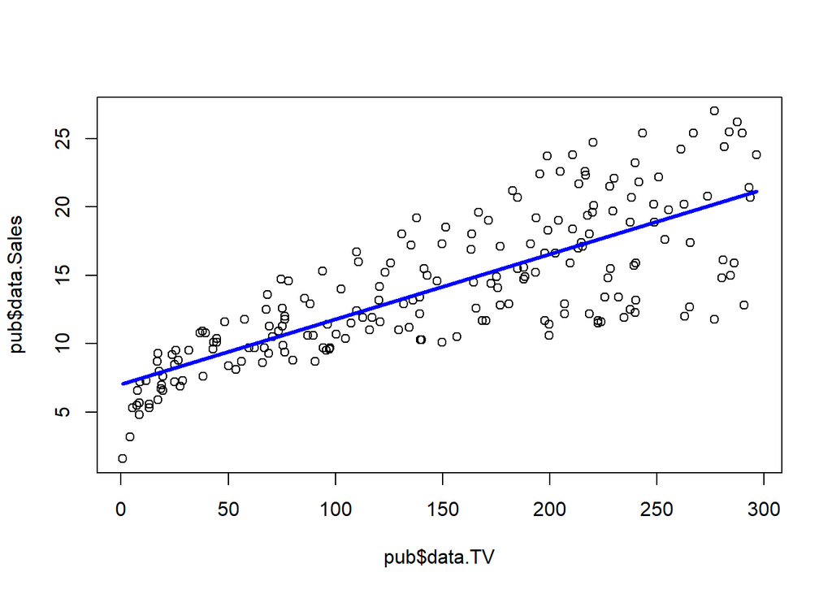

```r
plot(pub$data.TV,pub$data.Sales)
regTV=lm(data.Sales~data.TV,data=pub)
lines(c(min(pub$data.TV),max(pub$data.TV)),c(min(regTV$fitted.values),max(regTV$fitted.values)),col="blue",lwd=3)
```

```r
#plot(regTV)
summary(regTV)#plot(X=data.TV,Y=data.Sales,data=pub)
```

```
##
## Call:
## lm(formula = data.Sales ~ data.TV, data = pub)
##
## Residuals:
##     Min      1Q  Median      3Q     Max
## -8.3860 -1.9545 -0.1913  2.0671  7.2124
##
## Coefficients:
##             Estimate Std. Error t value Pr(>|t|)
## (Intercept) 7.032594   0.457843   15.36   <2e-16 ***
## data.TV     0.047537   0.002691   17.67   <2e-16 ***
## ---
## Signif. codes:  0 '***' 0.001 '**' 0.01 '*' 0.05 '.' 0.1 ' ' 1
##
## Residual standard error: 3.259 on 198 degrees of freedom
## Multiple R-squared:  0.6119, Adjusted R-squared:  0.6099
## F-statistic: 312.1 on 1 and 198 DF,  p-value: < 2.2e-16
```

```r
anova(regTV)
```

|  | Df | Sum Sq | Mean Sq | F value | Pr(>F) |
| --- | --- | --- | --- | --- | --- |
| data.TV | 1 | 3314.618 | 3314.61817 | 312.145 | 1.46739e-42 |
| Residuals | 198 | 2102.531 | 10.61884 | NA | NA |

Le modèle n’est pas ajusté aux données (R²=0,61). La pub sur la TV a un effet sur la vente (Fvalue=312).

##4/

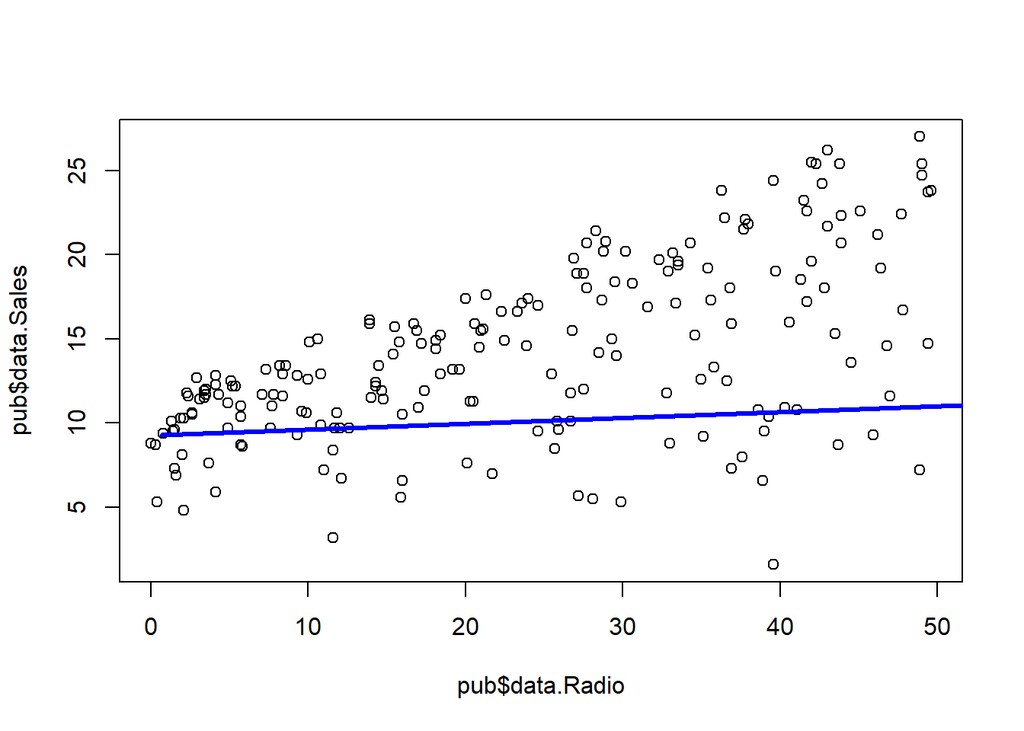

```r
plot(pub$data.Radio,pub$data.Sales)
regRadio=lm(data.Sales~data.Radio,data=pub)
lines(c(min(pub$data.TV),max(pub$data.TV)),c(min(regRadio$fitted.values),max(regRadio$fitted.values)),col="blue",lwd=3)
```

```r
#plot(regTV)
summary(regRadio)#plot(X=data.TV,Y=data.Sales,data=pub)
```

```
##
## Call:
## lm(formula = data.Sales ~ data.Radio, data = pub)
##
## Residuals:
##      Min       1Q   Median       3Q      Max
## -15.7305  -2.1324   0.7707   2.7775   8.1810
##
## Coefficients:
##             Estimate Std. Error t value Pr(>|t|)
## (Intercept)  9.31164    0.56290  16.542   <2e-16 ***
## data.Radio   0.20250    0.02041   9.921   <2e-16 ***
## ---
## Signif. codes:  0 '***' 0.001 '**' 0.01 '*' 0.05 '.' 0.1 ' ' 1
##
## Residual standard error: 4.275 on 198 degrees of freedom
## Multiple R-squared:  0.332,  Adjusted R-squared:  0.3287
## F-statistic: 98.42 on 1 and 198 DF,  p-value: < 2.2e-16
```

```r
anova(regRadio)
```

|  | Df | Sum Sq | Mean Sq | F value | Pr(>F) |
| --- | --- | --- | --- | --- | --- |
| data.Radio | 1 | 1798.669 | 1798.66920 | 98.42159 | 4.354966e-19 |
| Residuals | 198 | 3618.480 | 18.27515 | NA | NA |

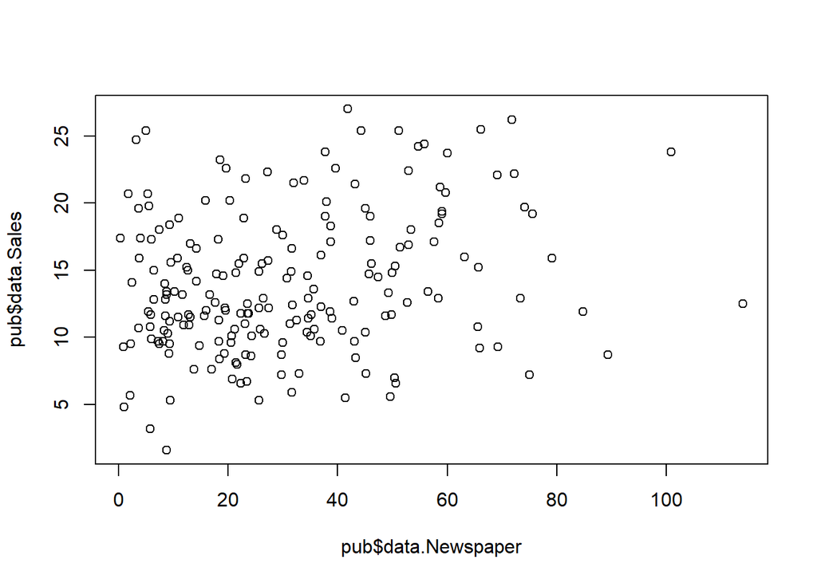

```r
plot(pub$data.Newspaper,pub$data.Sales)
```

```r
regNP=lm(data.Sales~data.Newspaper,data=pub)
#plot(regTV)
summary(regNP)#plot(X=data.TV,Y=data.Sales,data=pub)
```

```
##
## Call:
## lm(formula = data.Sales ~ data.Newspaper, data = pub)
##
## Residuals:
##      Min       1Q   Median       3Q      Max
## -11.2272  -3.3873  -0.8392   3.5059  12.7751
##
## Coefficients:
##                Estimate Std. Error t value Pr(>|t|)
## (Intercept)    12.35141    0.62142   19.88  < 2e-16 ***
## data.Newspaper  0.05469    0.01658    3.30  0.00115 **
## ---
## Signif. codes:  0 '***' 0.001 '**' 0.01 '*' 0.05 '.' 0.1 ' ' 1
##
## Residual standard error: 5.092 on 198 degrees of freedom
## Multiple R-squared:  0.05212,    Adjusted R-squared:  0.04733
## F-statistic: 10.89 on 1 and 198 DF,  p-value: 0.001148
```

```r
anova(regNP)
```

|  | Df | Sum Sq | Mean Sq | F value | Pr(>F) |
| --- | --- | --- | --- | --- | --- |
| data.Newspaper | 1 | 282.3442 | 282.34421 | 10.8873 | 0.001148196 |
| Residuals | 198 | 5134.8045 | 25.93336 | NA | NA |

##5/regression multiple

```r
reg=lm(data.Sales~data.TV+data.Radio+data.Newspaper,data=pub)
summary(reg)
```

```
##
## Call:
## lm(formula = data.Sales ~ data.TV + data.Radio + data.Newspaper,
##     data = pub)
##
## Residuals:
##     Min      1Q  Median      3Q     Max
## -8.8277 -0.8908  0.2418  1.1893  2.8292
##
## Coefficients:
##                 Estimate Std. Error t value Pr(>|t|)
## (Intercept)     2.938889   0.311908   9.422   <2e-16 ***
## data.TV         0.045765   0.001395  32.809   <2e-16 ***
## data.Radio      0.188530   0.008611  21.893   <2e-16 ***
## data.Newspaper -0.001037   0.005871  -0.177     0.86
## ---
## Signif. codes:  0 '***' 0.001 '**' 0.01 '*' 0.05 '.' 0.1 ' ' 1
##
## Residual standard error: 1.686 on 196 degrees of freedom
## Multiple R-squared:  0.8972, Adjusted R-squared:  0.8956
## F-statistic: 570.3 on 3 and 196 DF,  p-value: < 2.2e-16
```

```r
reg$coefficients
```

```
##    (Intercept)        data.TV     data.Radio data.Newspaper
##    2.938889369    0.045764645    0.188530017   -0.001037493
```

Concretement,B0 représente le nombre de ventes sans pub. Le poucentage de la variabilité des ventes est expliqué ici est de 89% (R²=0,89).

##6 et 7/regression multiple

```r
anova(reg)
```

|  | Df | Sum Sq | Mean Sq | F value | Pr(>F) |
| --- | --- | --- | --- | --- | --- |
| data.TV | 1 | 3.314618e+03 | 3.314618e+03 | 1.166731e+03 | 1.809337e-84 |
| data.Radio | 1 | 1.545617e+03 | 1.545617e+03 | 5.440501e+02 | 1.882722e-58 |
| data.Newspaper | 1 | 8.871717e-02 | 8.871717e-02 | 3.122805e-02 | 8.599151e-01 |
| Residuals | 196 | 5.568253e+02 | 2.840945e+00 | NA | NA |

Au moins une des variables ici TV et Radio sont significatives.

8/

```r
reg=lm(data.Sales~data.TV+data.Radio,data=pub)
summary(reg)
```

```
##
## Call:
## lm(formula = data.Sales ~ data.TV + data.Radio, data = pub)
##
## Residuals:
##     Min      1Q  Median      3Q     Max
## -8.7977 -0.8752  0.2422  1.1708  2.8328
##
## Coefficients:
##             Estimate Std. Error t value Pr(>|t|)
## (Intercept)  2.92110    0.29449   9.919   <2e-16 ***
## data.TV      0.04575    0.00139  32.909   <2e-16 ***
## data.Radio   0.18799    0.00804  23.382   <2e-16 ***
## ---
## Signif. codes:  0 '***' 0.001 '**' 0.01 '*' 0.05 '.' 0.1 ' ' 1
##
## Residual standard error: 1.681 on 197 degrees of freedom
## Multiple R-squared:  0.8972, Adjusted R-squared:  0.8962
## F-statistic: 859.6 on 2 and 197 DF,  p-value: < 2.2e-16
```

```r
reg$coefficients
```

```
## (Intercept)     data.TV  data.Radio
##  2.92109991  0.04575482  0.18799423
```

9/

```r
library(rgl)
library(car)
scatter3d(data.Sales~data.TV+data.Radio, data=pub)
```

10/

```r
x0=data.frame(data.TV=100,data.Radio=20)
borne=predict(reg,x0,interval='prediction')
borne
```

```
##        fit      lwr      upr
## 1 11.25647 7.929616 14.58332
```

on s’attend à vendre environ 11256 produits. L’intervalle est entre 7929 produits et 14583 produits.

#Exercice 3 1/

```r
tab=read.table("cafe.txt",header=T)
#summary(tab)
cafe=data.frame(tab)
summary(cafe)
```

```
##  origine     perte           lumin             xa               xb
##  A:50    Min.   :11.87   Min.   :15.06   Min.   : 5.730   Min.   : 6.42
##  B:42    1st Qu.:14.72   1st Qu.:19.78   1st Qu.: 8.620   1st Qu.:12.18
##  C:42    Median :16.41   Median :23.41   Median : 9.980   Median :16.30
##  D:13    Mean   :16.55   Mean   :24.03   Mean   : 9.938   Mean   :16.86
##  E:15    3rd Qu.:18.16   3rd Qu.:27.51   3rd Qu.:11.460   3rd Qu.:21.03
##  F:14    Max.   :22.81   Max.   :41.15   Max.   :13.130   Max.   :30.57
##  G:13
##        xy              xgn
##  Min.   : 1.920   Min.   :1.660
##  1st Qu.: 2.890   1st Qu.:2.420
##  Median : 3.790   Median :3.140
##  Mean   : 4.257   Mean   :3.466
##  3rd Qu.: 5.150   3rd Qu.:4.130
##  Max.   :11.970   Max.   :9.120
##
```

2/ (a)

```r
modele1=lm(perte~lumin+xa+xb+xy+xgn,data=cafe)
summary(modele1)
```

```
##
## Call:
## lm(formula = perte ~ lumin + xa + xb + xy + xgn, data = cafe)
##
## Residuals:
##      Min       1Q   Median       3Q      Max
## -2.67125 -0.54267  0.00579  0.48960  2.49762
##
## Coefficients:
##             Estimate Std. Error t value Pr(>|t|)
## (Intercept)  30.8410     2.8769  10.720  < 2e-16 ***
## lumin        -0.1305     0.2634  -0.496    0.621
## xa           -1.3470     0.1723  -7.819 4.06e-13 ***
## xb            0.2417     0.2117   1.142    0.255
## xy           -0.1623     0.1976  -0.821    0.413
## xgn          -0.3323     0.2216  -1.499    0.136
## ---
## Signif. codes:  0 '***' 0.001 '**' 0.01 '*' 0.05 '.' 0.1 ' ' 1
##
## Residual standard error: 0.8083 on 183 degrees of freedom
## Multiple R-squared:  0.8919, Adjusted R-squared:  0.889
## F-statistic:   302 on 5 and 183 DF,  p-value: < 2.2e-16
```

```r
modele1$coefficients
```

```
## (Intercept)       lumin          xa          xb          xy         xgn
##  30.8410003  -0.1305491  -1.3469711   0.2416761  -0.1623071  -0.3322836
```

```r
anova(modele1)
```

|  | Df | Sum Sq | Mean Sq | F value | Pr(>F) |
| --- | --- | --- | --- | --- | --- |
| lumin | 1 | 8.371655e+02 | 8.371655e+02 | 1.281214e+03 | 1.446230e-84 |
| xa | 1 | 1.451439e+02 | 1.451439e+02 | 2.221310e+02 | 2.079668e-33 |
| xb | 1 | 2.900799e+00 | 2.900799e+00 | 4.439437e+00 | 3.648054e-02 |
| xy | 1 | 5.048559e-03 | 5.048559e-03 | 7.726409e-03 | 9.300523e-01 |
| xgn | 1 | 1.468581e+00 | 1.468581e+00 | 2.247545e+00 | 1.355497e-01 |
| Residuals | 183 | 1.195751e+02 | 6.534159e-01 | NA | NA |

Les variables qui ont un effet significatif sont lumin, xa et xb.

```r
summary(modele1)
```

```
##
## Call:
## lm(formula = perte ~ lumin + xa + xb + xy + xgn, data = cafe)
##
## Residuals:
##      Min       1Q   Median       3Q      Max
## -2.67125 -0.54267  0.00579  0.48960  2.49762
##
## Coefficients:
##             Estimate Std. Error t value Pr(>|t|)
## (Intercept)  30.8410     2.8769  10.720  < 2e-16 ***
## lumin        -0.1305     0.2634  -0.496    0.621
## xa           -1.3470     0.1723  -7.819 4.06e-13 ***
## xb            0.2417     0.2117   1.142    0.255
## xy           -0.1623     0.1976  -0.821    0.413
## xgn          -0.3323     0.2216  -1.499    0.136
## ---
## Signif. codes:  0 '***' 0.001 '**' 0.01 '*' 0.05 '.' 0.1 ' ' 1
##
## Residual standard error: 0.8083 on 183 degrees of freedom
## Multiple R-squared:  0.8919, Adjusted R-squared:  0.889
## F-statistic:   302 on 5 and 183 DF,  p-value: < 2.2e-16
```

3/

```r
cor(cafe[,-1])
```

```
##            perte      lumin         xa         xb         xy        xgn
## perte  1.0000000 -0.8699159 -0.9340574 -0.9058234 -0.7980422 -0.8035131
## lumin -0.8699159  1.0000000  0.8643060  0.9895394  0.9717936  0.9661396
## xa    -0.9340574  0.8643060  1.0000000  0.9218400  0.7702314  0.7699353
## xb    -0.9058234  0.9895394  0.9218400  1.0000000  0.9405286  0.9350522
## xy    -0.7980422  0.9717936  0.7702314  0.9405286  1.0000000  0.9405116
## xgn   -0.8035131  0.9661396  0.7699353  0.9350522  0.9405116  1.0000000
```

On a xgn,xy et xa qui sont très corrélés avec lumin.

4/ (a)

```r
modele2=step(modele1, direction="backward")
```

```
## Start:  AIC=-74.52
## perte ~ lumin + xa + xb + xy + xgn
##
##         Df Sum of Sq    RSS     AIC
## - lumin  1     0.161 119.74 -76.271
## - xy     1     0.441 120.02 -75.829
## - xb     1     0.851 120.43 -75.184
## <none>               119.58 -74.525
## - xgn    1     1.469 121.04 -74.218
## - xa     1    39.953 159.53 -22.041
##
## Step:  AIC=-76.27
## perte ~ xa + xb + xy + xgn
##
##        Df Sum of Sq    RSS     AIC
## <none>              119.74 -76.271
## - xb    1     1.584 121.32 -75.788
## - xy    1     1.868 121.60 -75.345
## - xgn   1     4.547 124.28 -71.227
## - xa    1    48.311 168.05 -14.208
```

AIC plus petite que le START -> AIC la plus petite possible : arrêt de l’algo AIC=vraisemblance + pénalité liée au nombre de paramètre

```r
anova(modele2)
```

|  | Df | Sum Sq | Mean Sq | F value | Pr(>F) |
| --- | --- | --- | --- | --- | --- |
| xa | 1 | 965.170277 | 965.1702773 | 1483.195461 | 5.426576e-90 |
| xb | 1 | 14.762724 | 14.7627235 | 22.686157 | 3.855448e-06 |
| xy | 1 | 2.043827 | 2.0438273 | 3.140788 | 7.801177e-02 |
| xgn | 1 | 4.546516 | 4.5465161 | 6.986717 | 8.919952e-03 |
| Residuals | 184 | 119.735622 | 0.6507371 | NA | NA |

Les variables significatives sont xa,xb et xgn au risque de 5%

```r
summary(modele2)
```

```
##
## Call:
## lm(formula = perte ~ xa + xb + xy + xgn, data = cafe)
##
## Residuals:
##      Min       1Q   Median       3Q      Max
## -2.51027 -0.55664  0.01403  0.49402  2.48316
##
## Coefficients:
##             Estimate Std. Error t value Pr(>|t|)
## (Intercept) 29.45636    0.68578  42.953  < 2e-16 ***
## xa          -1.30678    0.15166  -8.616  3.1e-15 ***
## xb           0.14790    0.09481   1.560  0.12047
## xy          -0.23263    0.13730  -1.694  0.09189 .
## xgn         -0.41051    0.15530  -2.643  0.00892 **
## ---
## Signif. codes:  0 '***' 0.001 '**' 0.01 '*' 0.05 '.' 0.1 ' ' 1
##
## Residual standard error: 0.8067 on 184 degrees of freedom
## Multiple R-squared:  0.8918, Adjusted R-squared:  0.8894
## F-statistic:   379 on 4 and 184 DF,  p-value: < 2.2e-16
```

5/ (a)

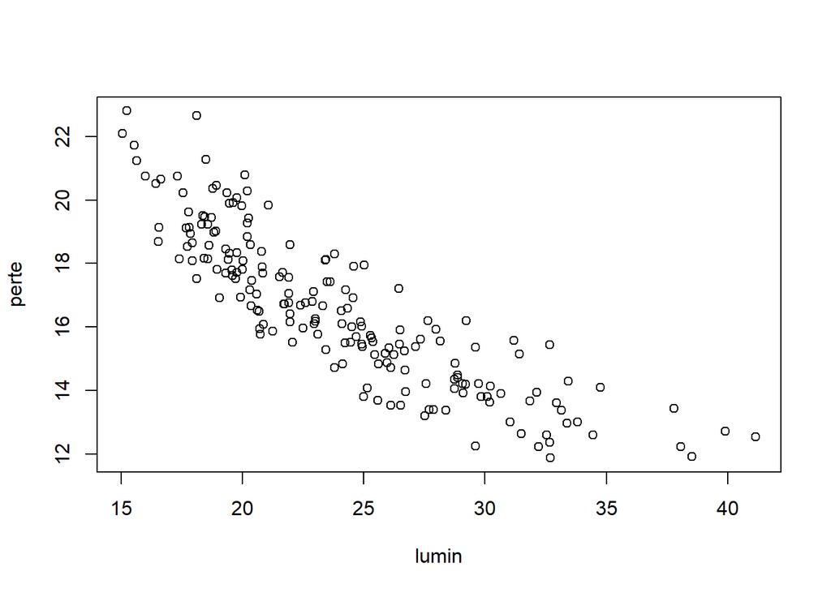

```r
plot(perte~lumin, data=cafe)
```

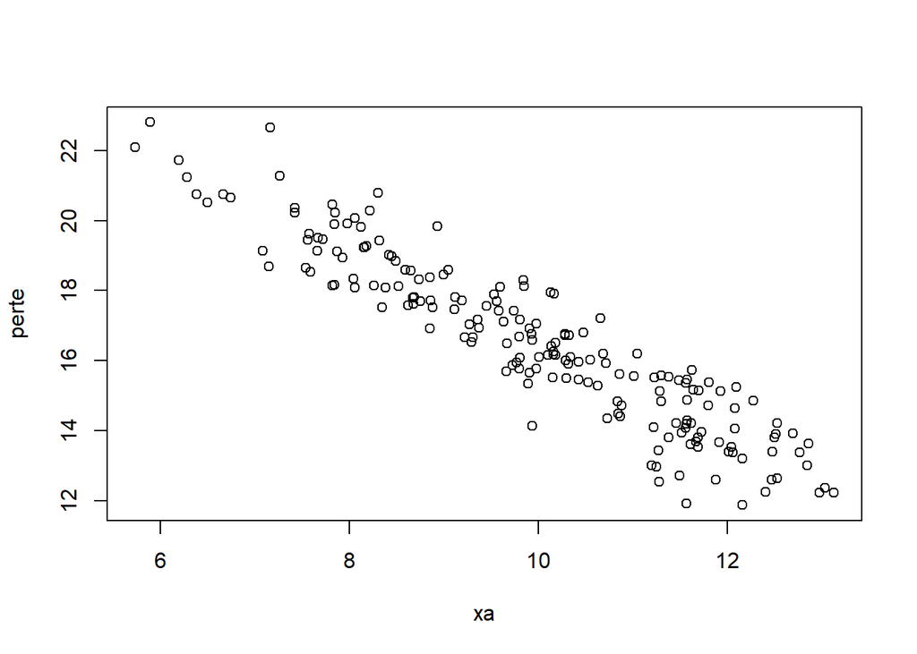

```r
plot(perte~xa, data=cafe)
```

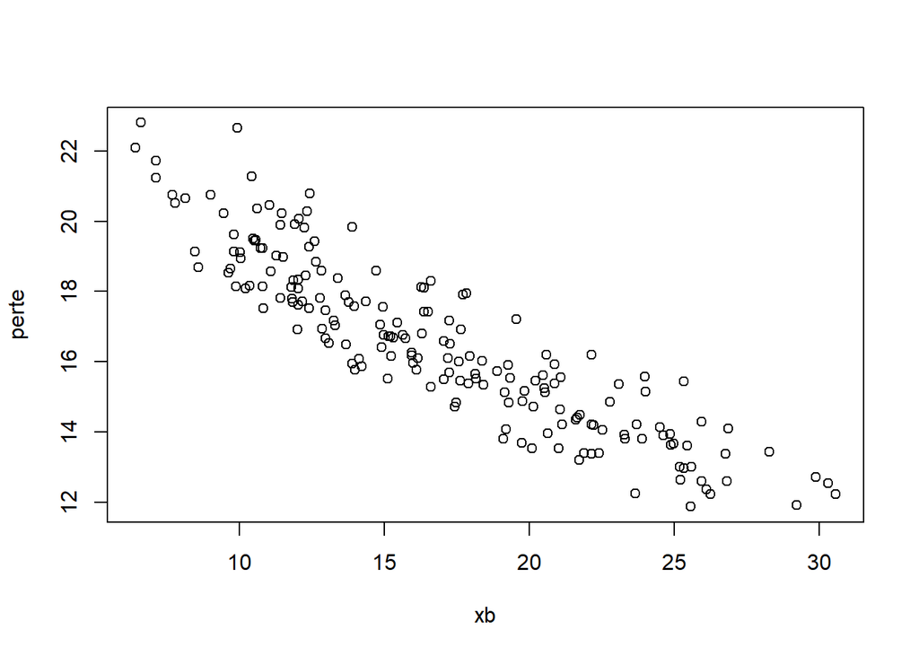

```r
plot(perte~xb, data=cafe)
```

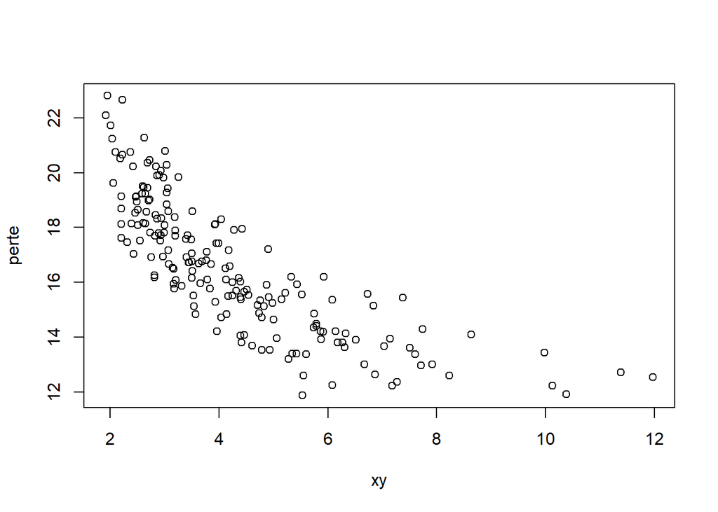

```r
plot(perte~xy, data=cafe)
```

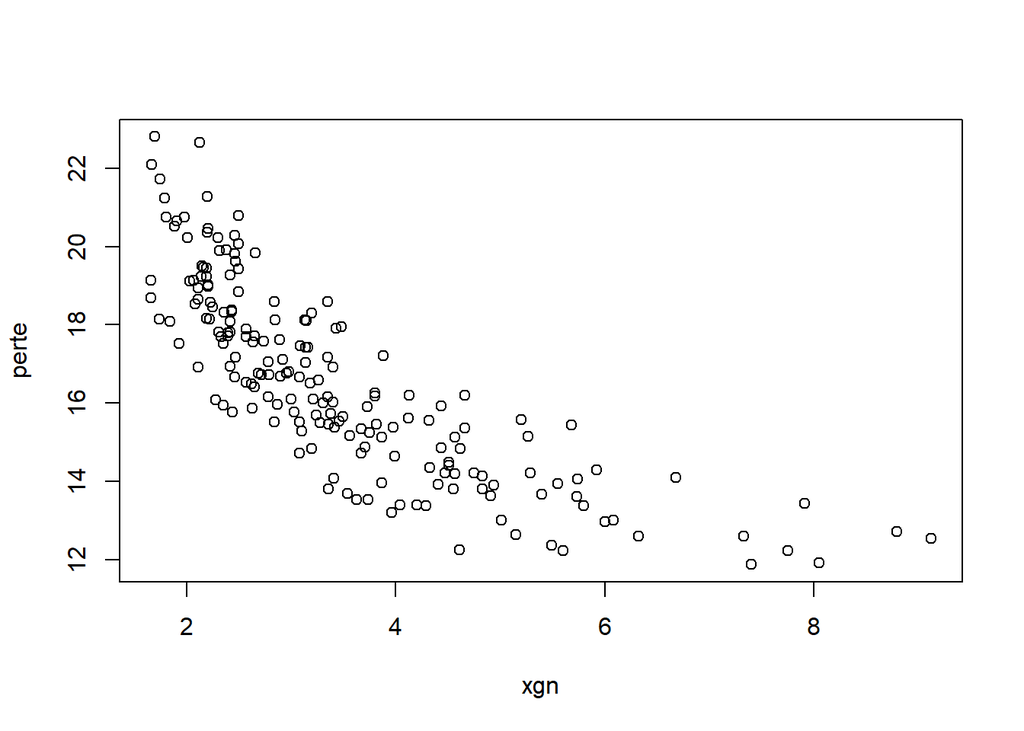

```r
plot(perte~xgn, data=cafe)
```

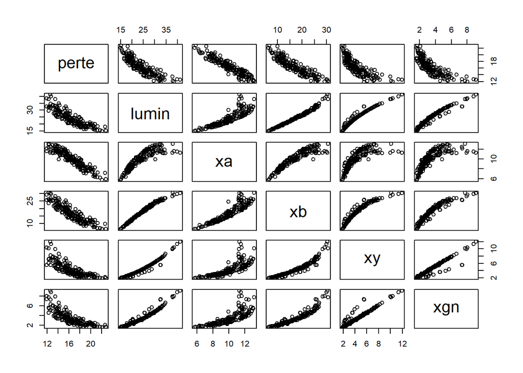

```r
pairs(cafe[,2:7])
```

Le choix du staticien est valable quant aux nouvelles variables pour voir si les variables expliquent mieux avec une courbe inverse(car pour lumin, xy et xgn on a l’impression de voir une fonction inverse).

```r
cafe2=data.frame(cafe,Tlumin=1/cafe$lumin,Txy=1/cafe$xy,Txgn=1/cafe$xgn)
```

```r
modele3=lm(perte~lumin+xa+xb+xy+xgn+Tlumin+Txy+Txgn,data=cafe2)
summary(modele3)
```

```
##
## Call:
## lm(formula = perte ~ lumin + xa + xb + xy + xgn + Tlumin + Txy +
##     Txgn, data = cafe2)
##
## Residuals:
##      Min       1Q   Median       3Q      Max
## -2.54030 -0.57527 -0.03807  0.53348  2.93653
##
## Coefficients:
##              Estimate Std. Error t value Pr(>|t|)
## (Intercept)  23.45481   10.72459   2.187   0.0300 *
## lumin         0.02016    0.46078   0.044   0.9652
## xa           -1.29614    0.18244  -7.105 2.72e-11 ***
## xb            0.15761    0.22649   0.696   0.4874
## xy           -0.06774    0.36779  -0.184   0.8541
## xgn          -0.64787    0.40310  -1.607   0.1098
## Tlumin      293.39275  145.66016   2.014   0.0455 *
## Txy          -8.59677    4.95488  -1.735   0.0845 .
## Txgn        -15.29300    4.31368  -3.545   0.0005 ***
## ---
## Signif. codes:  0 '***' 0.001 '**' 0.01 '*' 0.05 '.' 0.1 ' ' 1
##
## Residual standard error: 0.783 on 180 degrees of freedom
## Multiple R-squared:  0.9003, Adjusted R-squared:  0.8958
## F-statistic: 203.1 on 8 and 180 DF,  p-value: < 2.2e-16
```

```r
modele3$coefficients
```

```
##  (Intercept)        lumin           xa           xb           xy
##  23.45480635   0.02015892  -1.29613522   0.15761322  -0.06774019
##          xgn       Tlumin          Txy         Txgn
##  -0.64786862 293.39274602  -8.59677287 -15.29300222
```

```r
modele4=step(modele3, direction="backward")
```

```
## Start:  AIC=-83.7
## perte ~ lumin + xa + xb + xy + xgn + Tlumin + Txy + Txgn
##
##          Df Sum of Sq    RSS     AIC
## - lumin   1    0.0012 110.35 -85.698
## - xy      1    0.0208 110.37 -85.665
## - xb      1    0.2969 110.65 -85.192
## <none>                110.35 -83.700
## - xgn     1    1.5836 111.93 -83.007
## - Txy     1    1.8454 112.19 -82.566
## - Tlumin  1    2.4872 112.84 -81.487
## - Txgn    1    7.7053 118.06 -72.943
## - xa      1   30.9433 141.29 -38.983
##
## Step:  AIC=-85.7
## perte ~ xa + xb + xy + xgn + Tlumin + Txy + Txgn
##
##          Df Sum of Sq    RSS     AIC
## - xy      1     0.054 110.40 -87.606
## - xb      1     0.889 111.24 -86.181
## <none>                110.35 -85.698
## - Txy     1     2.136 112.49 -84.075
## - xgn     1     4.768 115.12 -79.704
## - Tlumin  1     5.145 115.50 -79.085
## - Txgn    1     9.080 119.43 -72.753
## - xa      1    46.487 156.84 -21.255
##
## Step:  AIC=-87.61
## perte ~ xa + xb + xgn + Tlumin + Txy + Txgn
##
##          Df Sum of Sq    RSS     AIC
## - xb      1     0.926 111.33 -88.027
## <none>                110.40 -87.606
## - Txy     1     2.244 112.65 -85.803
## - Tlumin  1     5.114 115.52 -81.047
## - xgn     1     6.293 116.70 -79.129
## - Txgn    1    10.255 120.66 -72.819
## - xa      1    59.960 170.37  -7.619
##
## Step:  AIC=-88.03
## perte ~ xa + xgn + Tlumin + Txy + Txgn
##
##          Df Sum of Sq    RSS     AIC
## <none>                111.33 -88.027
## - Txy     1     2.839 114.17 -85.267
## - Tlumin  1     4.190 115.52 -83.044
## - Txgn    1     9.352 120.68 -74.782
## - xgn     1    10.258 121.59 -73.368
## - xa      1    87.394 198.72  19.483
```

```r
anova(modele4)
```

|  | Df | Sum Sq | Mean Sq | F value | Pr(>F) |
| --- | --- | --- | --- | --- | --- |
| xa | 1 | 965.1702773 | 965.1702773 | 1586.5018781 | 4.260511e-92 |
| xgn | 1 | 19.3291512 | 19.3291512 | 31.7723571 | 6.467356e-08 |
| Tlumin | 1 | 0.7682980 | 0.7682980 | 1.2628924 | 2.625763e-01 |
| Txy | 1 | 0.3082557 | 0.3082557 | 0.5066963 | 4.774790e-01 |
| Txgn | 1 | 9.3524126 | 9.3524126 | 15.3730595 | 1.246258e-04 |
| Residuals | 183 | 111.3305715 | 0.6083638 | NA | NA |

modele variables stepwide = les 2 ajouts et suppressions de variables

```r
modele5=step(modele3, direction="both")
```

```
## Start:  AIC=-83.7
## perte ~ lumin + xa + xb + xy + xgn + Tlumin + Txy + Txgn
##
##          Df Sum of Sq    RSS     AIC
## - lumin   1    0.0012 110.35 -85.698
## - xy      1    0.0208 110.37 -85.665
## - xb      1    0.2969 110.65 -85.192
## <none>                110.35 -83.700
## - xgn     1    1.5836 111.93 -83.007
## - Txy     1    1.8454 112.19 -82.566
## - Tlumin  1    2.4872 112.84 -81.487
## - Txgn    1    7.7053 118.06 -72.943
## - xa      1   30.9433 141.29 -38.983
##
## Step:  AIC=-85.7
## perte ~ xa + xb + xy + xgn + Tlumin + Txy + Txgn
##
##          Df Sum of Sq    RSS     AIC
## - xy      1     0.054 110.40 -87.606
## - xb      1     0.889 111.24 -86.181
## <none>                110.35 -85.698
## - Txy     1     2.136 112.49 -84.075
## + lumin   1     0.001 110.35 -83.700
## - xgn     1     4.768 115.12 -79.704
## - Tlumin  1     5.145 115.50 -79.085
## - Txgn    1     9.080 119.43 -72.753
## - xa      1    46.487 156.84 -21.255
##
## Step:  AIC=-87.61
## perte ~ xa + xb + xgn + Tlumin + Txy + Txgn
##
##          Df Sum of Sq    RSS     AIC
## - xb      1     0.926 111.33 -88.027
## <none>                110.40 -87.606
## - Txy     1     2.244 112.65 -85.803
## + xy      1     0.054 110.35 -85.698
## + lumin   1     0.034 110.37 -85.665
## - Tlumin  1     5.114 115.52 -81.047
## - xgn     1     6.293 116.70 -79.129
## - Txgn    1    10.255 120.66 -72.819
## - xa      1    59.960 170.37  -7.619
##
## Step:  AIC=-88.03
## perte ~ xa + xgn + Tlumin + Txy + Txgn
##
##          Df Sum of Sq    RSS     AIC
## <none>                111.33 -88.027
## + xb      1     0.926 110.40 -87.606
## + lumin   1     0.416 110.91 -86.735
## + xy      1     0.091 111.24 -86.181
## - Txy     1     2.839 114.17 -85.267
## - Tlumin  1     4.190 115.52 -83.044
## - Txgn    1     9.352 120.68 -74.782
## - xgn     1    10.258 121.59 -73.368
## - xa      1    87.394 198.72  19.483
```

```r
anova(modele5)
```

|  | Df | Sum Sq | Mean Sq | F value | Pr(>F) |
| --- | --- | --- | --- | --- | --- |
| xa | 1 | 965.1702773 | 965.1702773 | 1586.5018781 | 4.260511e-92 |
| xgn | 1 | 19.3291512 | 19.3291512 | 31.7723571 | 6.467356e-08 |
| Tlumin | 1 | 0.7682980 | 0.7682980 | 1.2628924 | 2.625763e-01 |
| Txy | 1 | 0.3082557 | 0.3082557 | 0.5066963 | 4.774790e-01 |
| Txgn | 1 | 9.3524126 | 9.3524126 | 15.3730595 | 1.246258e-04 |
| Residuals | 183 | 111.3305715 | 0.6083638 | NA | NA |

6/

```r
extractAIC(modele1)
```

```
## [1]   6.00000 -74.52464
```

```r
extractAIC(modele2)
```

```
## [1]   5.0000 -76.2711
```

```r
extractAIC(modele3)
```

```
## [1]   9.00000 -83.70015
```

```r
extractAIC(modele4)
```

```
## [1]   6.00000 -88.02695
```

Le meilleur modèle en terme de AIC est le modèle 4.

```r
res1=summary(modele1)
res1$adj.r.squared
```

```
## [1] 0.8889571
```

```r
res2=summary(modele2)
res2$adj.r.squared
```

```
## [1] 0.8894124
```

```r
res3=summary(modele3)
res3$adj.r.squared
```

```
## [1] 0.8958167
```

```r
res4=summary(modele4)
res4$adj.r.squared
```

```
## [1] 0.8966134
```

Le meilleur modèle en terme de R² est le modèle 4.

Dans R, ajuster c’est pour la régression multiple.